# ProjectT2 (3)

Output

```python
labels.shape
```

```
(4000,)
```

```python
labels
```

```
array([1, 1, 1, ..., 0, 0, 0])
```

- As data present in labels is either ships(1) or not ships(0). So here data is represented in form of 0's and 1's.

```python
np.bincount(labels)

#1000 images are tagged as ships
#3000 images are tagged as not ships
```

```
array([3000, 1000])
```

Preparing data

```python
Y= to_categorical(labels,2)
print(Y.shape)
```

```
(4000, 2)
```

```python
#shuffle all indexes

indexes = np.arange(4000)
np.random.shuffle(indexes)
```

```python
#traversing of images

X_train = X[indexes]
y_train = labels[indexes]
```

```python
#scaling

X_train = X_train / 255
```

Training Model

```python
np.random.seed(42)
```

```python
#building model

model = Sequential()
#first layer we need to mention input shape
model.add(Conv2D(16,3, padding='same', input_shape=(80,80,3), activation='relu'))
model.add(MaxPooling2D(pool_size=(2, 2)))
#add a conv layer followed by maxpooling
# Size of activation layer is 80*80*3=19200

#add a conv layer followed by maxpooling
model.add(Conv2D(32,3,padding='same', activation='relu'))
model.add(MaxPooling2D(pool_size=(2, 2))) #20x20

#add a conv layer followed by maxpooling
model.add(Conv2D(64,3, padding='same', activation='relu'))
model.add(MaxPooling2D(pool_size=(2, 2))) #10x10

#add a conv layer followed by maxpooling
model.add(Conv2D(32,3, padding='same', activation='relu'))
model.add(MaxPooling2D(pool_size=(2, 2))) #5x5

#convert feature map in 1d array
model.add(Flatten())
#fully connected layer with 512 neurons
model.add(Dense(512, activation='relu'))

#final layer
model.add(Dense(1, activation='sigmoid'))
#summary
model.summary()
```

```
Model: "sequential_8"
_________________________________________________________________
Layer (type)                 Output Shape              Param #
=================================================================
conv2d_29 (Conv2D)           (None, 80, 80, 16)        448
_________________________________________________________________
max_pooling2d_29 (MaxPooling (None, 40, 40, 16)        0
_________________________________________________________________
conv2d_30 (Conv2D)           (None, 40, 40, 32)        4640
_________________________________________________________________
max_pooling2d_30 (MaxPooling (None, 20, 20, 32)        0
_________________________________________________________________
conv2d_31 (Conv2D)           (None, 20, 20, 64)        18496
_________________________________________________________________
max_pooling2d_31 (MaxPooling (None, 10, 10, 64)        0
_________________________________________________________________
conv2d_32 (Conv2D)           (None, 10, 10, 32)        18464
_________________________________________________________________
max_pooling2d_32 (MaxPooling (None, 5, 5, 32)          0
_________________________________________________________________
flatten_8 (Flatten)          (None, 800)               0
_________________________________________________________________
dense_15 (Dense)             (None, 512)               410112
_________________________________________________________________
dense_16 (Dense)             (None, 1)                 513
=================================================================
Total params: 452,673
Trainable params: 452,673
Non-trainable params: 0
_________________________________________________________________
```

```python
#compiling model

model.compile(optimizer='adam',loss=tf.keras.losses.BinaryCrossentropy(),metrics=['accuracy'])
```

```python
#fitting model

history=model.fit(X_train,y_train,epochs=15,batch_size=32,validation_split=0.2,shuffle=True)
```

```
Train on 3200 samples, validate on 800 samples
```

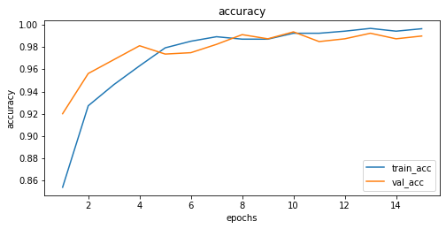

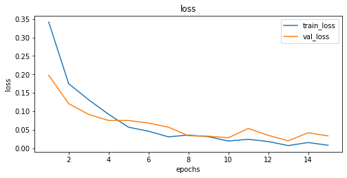

```python
#visualizing the accuracy and loss of train and validation

train_accuracy=history.history['accuracy']
val_acc=history.history['val_accuracy']
train_loss=history.history['loss']
val_loss=history.history['val_loss']
epoches=list(range(1,16))

plt.figure(figsize=(8,8)) #figure size
plt.subplot(2,1,1)
plt.plot(epoches,train_accuracy,label='train_acc')
plt.plot(epoches,val_acc,label='val_acc')
plt.title('accuracy') #title of the graph
plt.ylabel('accuracy') #label of y-axis
plt.xlabel('epochs') #label of x-axis
plt.legend(loc='lower right') #legend of accuracy graph

plt.figure(figsize=(8,8)) #figure size
plt.subplot(2,1,2)
plt.plot(epoches,train_loss,label='train_loss')
plt.plot(epoches,val_loss,label='val_loss')
plt.title('loss') #title of loss graph
plt.xlabel('epochs') #label for x-axis
plt.ylabel('loss') #label for y-axis
plt.legend() #legend for loss graph
```

- As we can see in the above graphs data is not overfitted and at the same time data is not underfitted.
- So, we can say that the model is working as expected.

Testing

```python
from tensorflow.keras.preprocessing import image #importing required packages for prediction
import numpy as np
img=image.load_img('/content/drive/My Drive/projectDS/shipsnet/xshipsnet/0__20150830_000650_0b07__-122.37967271362145_37.76049394246638.png') #loading image from dataset
print(type(img)) #printing the type of image
img=tf.keras.preprocessing.image.img_to_array(img) #converting image to numpy array
print(type(img)) #printing the type of image
img=tf.image.resize(img,(80,80)) #resizing image to (80,80)
img=img/255 #scaling the image
print(img.shape)
img=np.expand_dims(img,axis=0)
print(img.shape)
```

```
<class 'PIL.PngImagePlugin.PngImageFile'>
<class 'numpy.ndarray'>
(80, 80, 3)
(1, 80, 80, 3)
```

```python
model.predict(img)
```

```
array([[0.00010439]], dtype=float32)
```

```python
if(model.predict(img)==1):
  print("ship")
else:
  print('not ship')
```

```
not ship
```

Since the predict value is less than 0.5 it is predicting correctly that it is not a ship.

```python
#reading of image from dataset and testing it

from tensorflow.keras.preprocessing import image
import numpy as np
img=image.load_img('/content/drive/My Drive/projectDS/scenes/xscenes/lb_5.png') #loading image from dataset
print(type(img)) #printing the type of image
img=tf.keras.preprocessing.image.img_to_array(img) #converting image to numpy array
print(type(img)) #printing the type of image
img=tf.image.resize(img,(80,80)) #resizing image to (80,80)
img=img/255 #scaling the image
print(img.shape)
img=np.expand_dims(img,axis=0)
print(img.shape)
```

```
<class 'PIL.PngImagePlugin.PngImageFile'>
<class 'numpy.ndarray'>
(80, 80, 3)
(1, 80, 80, 3)
```

```python
#predicting the image by using our model

model.predict(img)
```

```
array([[0.99998915]], dtype=float32)
```

since the value is close to 1 it is classified as a ship

Testing external image

```python
from tensorflow.keras.preprocessing import image
import numpy as np
img=image.load_img('/content/drive/My Drive/projectDS/ExtTest.png') #loading image from dataset
print(type(img)) #printing the type of image
img=tf.keras.preprocessing.image.img_to_array(img) #converting image to numpy array
print(type(img)) #printing the type of image
img=tf.image.resize(img,(80,80)) #resizing image to (80,80)
img=img/255 #scaling the image
print(img.shape) #printing the shape of image as we reshaped it previously
img=np.expand_dims(img,axis=0)
print(img.shape)
```

```
<class 'PIL.PngImagePlugin.PngImageFile'>
<class 'numpy.ndarray'>
(80, 80, 3)
(1, 80, 80, 3)
```

```python
model.predict(img)
```

```
array([[1.]], dtype=float32)
```

```python
if(model.predict(img)==1):
  print("ship")
else:
  print('not ship')
```

```
ship
```